# Did the pandemic help the enviroment?

Mariel Ellingsen, Steinar Hansen og Helle Sandsdalen

# Introduction and motivation

There is no question about what the biggest challenge of the 21st century is: Global climate changes. When we talk about the climate changes, it’s important to emphasize that it is the human induced climate changes we are referring to. Some of the climate changes include global warming, rising sea levels and irregular downpour. Both the industry and general public is responsible for releasing a high emission of greenhouse gasses by e.g. burning fossil fuel. While these effects may not be as visible in your daily life, another byproduct of the increasing pollution is the air quality, which influences us more in our daily lives.

In 2019 the [European Environment Agency](https://www.eea.europa.eu/media/infographics/co2-emissions-from-passenger-transport/view) came out with an overview of the amount of CO$_{2}$ emissions of passenger transportation, and it states that the emission for traveling with a plane is 285 g CO$_{2}$ per passenger per km, in contrast with an average car where the emission is 55 g of CO$_{2}$ per passenger per km.

One of the first restrictions that most countries made when the covid-19 virus became classified as a pandemic, was travelling restrictions. This in theory would dramatically impact the air traffic with both domestic and foreign travel.

This made us wonder *if the pandemic practically affected the air traffic, did it by default then also affect the air quality?*

# Preperatory work

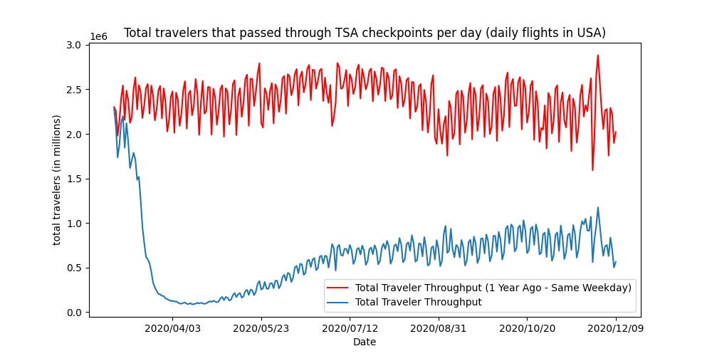

The results we found were quite interesting, and we decided to further investigate the air traffic. We were also interested to see if there were any difference between the continents around the world and we therefore picked three different airports from Asia, the USA and Europe to find out more about this.

Since airplanes pollute the air the most per passenger, we further wanted to investigate if the air quality of the respective cities were improved if the decrease in air traffic were noticeable high.

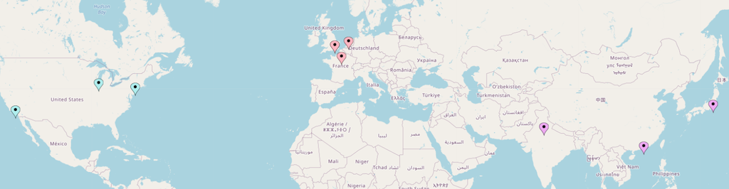

# Related work

### Air traffic

In the preparation phase, we also looked around for other research on how Covid-19 has affected the air traffic. There are several articles and researches around the internet.

The articles [“Impact of COVID-19 on worldwide aviation”](https://traffic-viz.github.io/scenarios/covid19.html) and [“Visualization of Air Traffic during Covid-19 pandemic”](https://towardsdatascience.com/visualization-of-air-traffic-during-covid-19-pandemic-c5941b049401) compare and analyse the impact covid-19 has had on aviation, and use methods to analyse and visualize the data similar to what we desire to use. Both articles have taken a subset of data from available airports to visualize the global effect the pandemic has had the air traffic. One of the articles compares how the passenger traffic by air decreased a lot while the cargo air traffic was not remarkably affected.

It also looks at how different airlines, and how they individually were affected compared to each other. But in both articles, they conclude that the aviation decreased a lot due to the lockdown caused by the pandemic.

### Air pollution

The article [“The short-term impacts of COVID-19 lockdown on urban air pollution in China”](https://www.nature.com/articles/s41893-020-0581-y) have measured and analysed the air quality in terms of the AQI (Air quality index) and the concentrations of particulate matter with a diameter of less than 2.5 μm (PM2.5).

After their experiments and analysis, they conclude that there has been a difference in air quality, but it is unknown if it’s only an one-time shock where the previous air quality will regress when people resume their normal activity, or if it can have had a stronger and more permanent impact that will only be known to us in the future.

# Data collection and preparation

### Preperatory work data

The data we used in our preparatory work was gathered from the TSA website using a web scraping technique with the programming language Python. The data was collected and treated before using a library called matplotlib to display it.

### Flight data

The air traffic data used is crowded sourced air traffic data from the [OpenSky Network 2020](http://doi.org/10.5281/zenodo.4299837) (version v20.11). Their data disclaimer:

#### Disclaimer from OpenSky Network 2020:

The data provided in the files is provided as is. Despite our best efforts at filtering out potential issues, some information could be erroneous.

- Origin and destination airports are computed online based on the ADS-B trajectories on approach/takeoff: no crosschecking with external sources of data has been conducted. Fields **origin** or **destination** are empty when | no airport could be found.
- Aircraft information come from the OpenSky aircraft database. Fields **typecode** and **registration** are empty when the aircraft is not present in the database.

With this in mind, the data would not be exact, but it gives a good estimate and we therefore thought it would give us the data we needed in terms of this research. We first thought of using data from https://www.flightradar24.com/, which may have more accurate data, but this source demands payment for historical data.

Data sets from 2019-01-01 until 2020-10-31 are downloaded and simplified. The data sets are simplified such that there is one dataframe per airport with daily data. Each data frame contains total flights on each day, as well as calculating 7 days rolling average as well as 30 days rolling average. These datasets are used for analysis and visualization.

We have used the origin and destination columns in the datasets to calculate how many aircrafts leaving or approaching the respective airports. When the columns origin or destination in the original data sets is empty, they are ignored and not counted on one of our chosen airports.

### Air data

The air quality data used in this survey is collected from the [World Air Quality Index project](https://aqicn.org). This collects data from many open quality sources around the world, including government funded sensor data and independent sensors. This results in a very comprehensive set of air quality sensor data from many cities around the world.

The datasets downloaded from aqicn show the computed air quality index for the measured pollutant concentrations. Air Quality Index is a value that represents the air quality of the air calculated from the measured pollutants. The value is divided into six ranges, from good at 0-50 AQI to hazardous at 300+ AQI. The individual values are calculated based on the US EPA [scale](https://www.airnow.gov/aqi/aqi-basics/). The total aqi is the maximal value of any of the pollutants.

As our focus is on comparing air quality related to air travel we chose to use the measuring station closest to the airport when possible. We tried to probe for stations that provided reliable measurements over the estimation period which led to us sometimes picking a station further from the given airport. A disadvantage of using only one measuring station is there could be selection biases from our end where we only use stations that prove our theory or the station measurements could be biased in one direction or another.

It should also be mentioned that air quality can be affected by many different factors. In 2017 27% of emissions came from the transport sector, of which 71% came from the automotive industry and only 14% came from aviation. [Source.](https://www.eea.europa.eu/data-and-maps/indicators/transport-emissions-of-greenhouse-gases/transport-emissions-of-greenhouse-gases-12)

# Exploratory Analysis

The goal of the visualisation of the gathered data, was to see if there was a dip in aviation during lockdown months, if there was a clear distinction in air quality after the lockdown months, and if both the air traffic and air quality plots would have a coherence.

To analyze and visualize the air traffic we used the data in different ways. First we extracted only the total number of flights per month per airport. From this it was possible to see the desired results, but it did not depict the movement of the data.

Further, we extracted daily data for the airports which we used to calculate both 7 and 30 days rolling average and plotted this instead. This was a better way to see the movement of the data, as well as it depicted the desired results. After analyzing both the 7 and 30 days rolling average, we concluded that the 30 days moving average was sufficient to see both the data movement and the results.

At last, to get an overall insight on the global impact, we summarized all the 30 days moving average of the respective airports. This way, we could clearly see the impact that covid-19 had globally, from our airports.

We also calculated some broader statistics for air quality to better show how the air quality improved throughout the year. Since the lockdown was enforced stronger in the first half of the year we found the mean AQI for the first and second half of 2019 and 2020 and calculated how much it improved.

# Final analysis

### Aviation

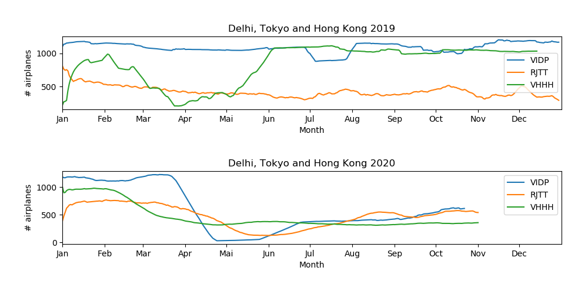

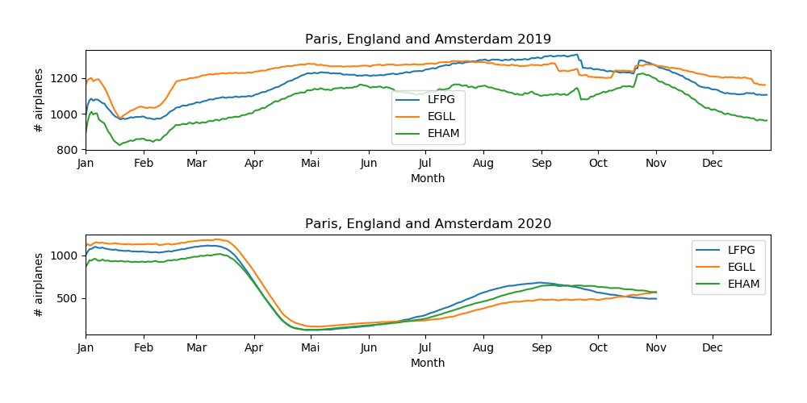

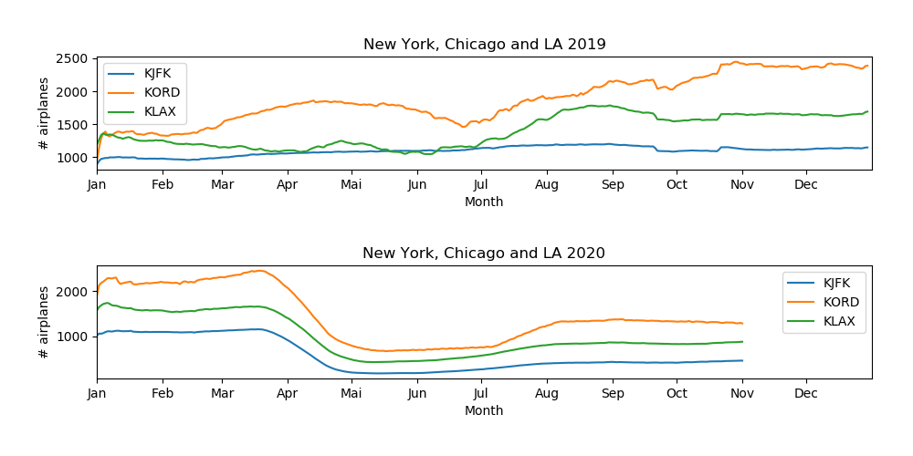

As the pandemic spread world wide, the countries around the world had to make drastic changes to try to control the spread of the virus. One of the restrictions almost all countries made was to lock down the cities and close their borders to tourists and immigrants. In theory, this would naturally decrease the aviation to and from these airports.

What we can conclude from these findings, and the graphs depicted above, is that covid-19 had a massive effect on global aviation. Since the countries around the world had to close their borders the foreign flights from these airports stopped, as well as many domestic flights because of city lockdowns.

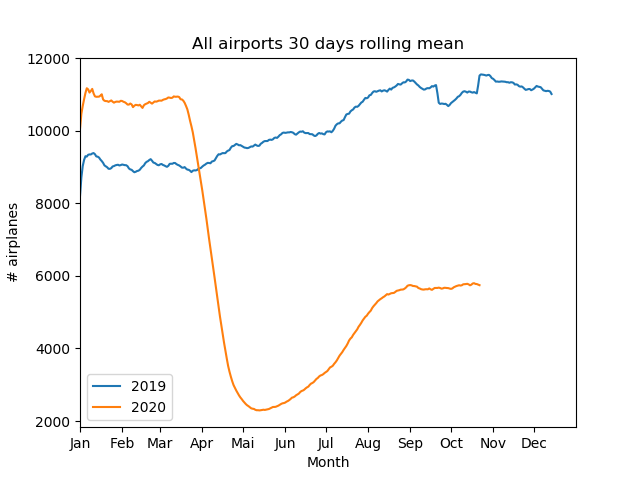

To summarize, global aviation has suffered a high decrease due to the global pandemic caused by covid-19. Due to the interesting findings which substantiates our original hypothesis, we further investigated if the reduction in aviation traffic had any impact on the air quality of the respective cities.

### Air quality

Air quality

| Period of measurement | Global mean 2019 | Global mean 2020 | Percentage improvement |
| --- | --- | --- | --- |
| first half of year | 58.28 | 46.66 | 19.94% |
| last half of year | 57.52 | 50.94 | 11.44% |
| entire year | 58.04 | 49.10 | 15.40% |

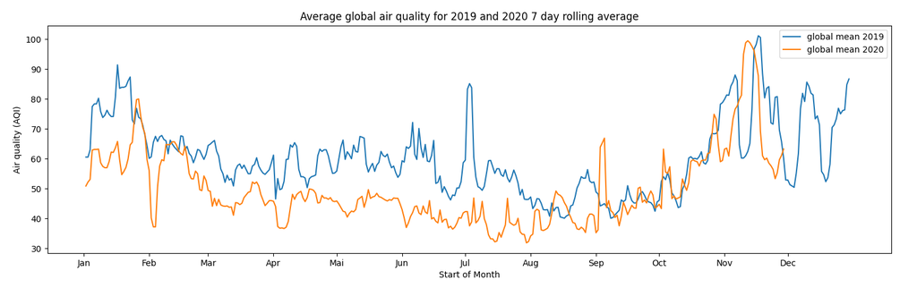

From this we can see that the air quality in Asia was better for longer than in Europe and the USA. The average air quality in Asia went from 109 in 2019 to 86 in 2020, and into around 50 at times. This gets Asia almost to the quality level of Europe and America, who generally has very good air quality. In fact it seems as if the air quality in Europe was not affected very much by the lockdown, the average in Europe was 34 in 2019 and 31 in 2020. America was slightly more affected going from 36 to 32 but these are both well within the good category for the air quality index. Asia did however drop from unhealthy to moderate on average which will be a significant improvement for the general population.

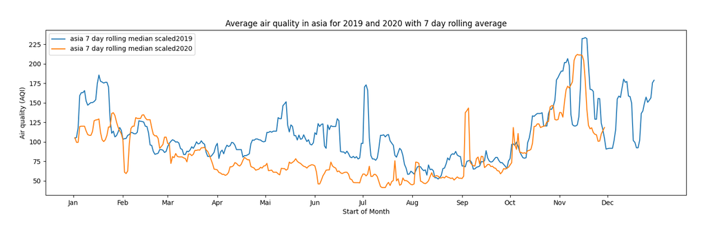

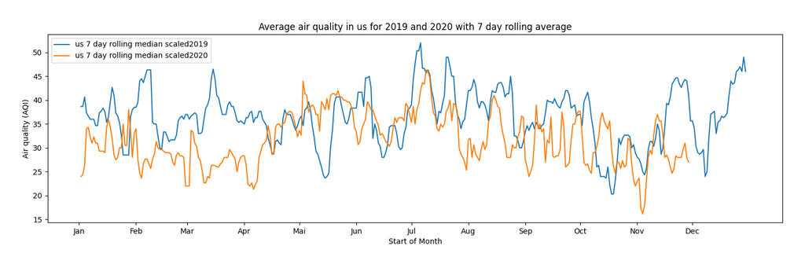

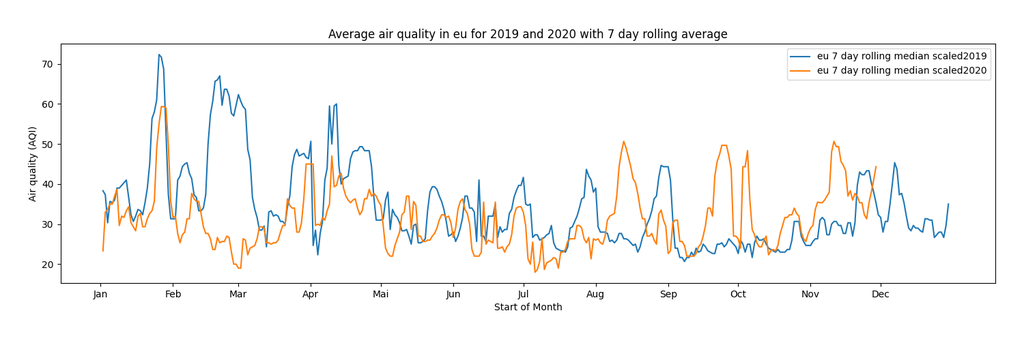

Ultimately our findings here are not enough to conclude that the drop in aviation caused improved air quality, as we do not control for other pollutants such as factory emissions, road transport or maritime transport. We can however conclude that both aviation and air quality were independently significantly affected by the global lockdown.